# Inferential Data Analysis Of The ToothGrowth Dataset

Damian Grasso

# Overview

The ToothGrowth dataset measures the length of odontoblasts (cells responsible for tooth growth) in 60 guinea pigs, based on variable doses of supplements Orange Juice (OJ) or Ascorbic Acid (VC).

This project aims to identify which of the supplements is most effective at doses of 0.5mg/day, 1mg/day, 2mg/day and overall.

The data used to validate the experiment captures the length of odontoblasts (len), the supplement (supp) taken and dose for each guinea pig:

|  | len | supp | dose |
| --- | --- | --- | --- |
| 1 | 4.2 | VC | 0.5 |
| 2 | 11.5 | VC | 0.5 |
| 3 | 7.3 | VC | 0.5 |
| 4 | 5.8 | VC | 0.5 |
| 5 | 6.4 | VC | 0.5 |
| 6 | 10.0 | VC | 0.5 |

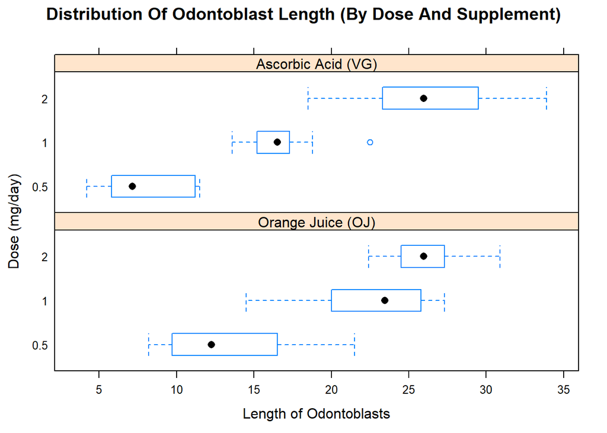

## Key Assumptions

# Experiments

## Experiment 1 - 0.5 mg/day Dose

A null hypothesis (H0) and alternate hypothesis (Ha) chosen to test this experiment are:

- H0: There is NO DIFFERENCE in the MEAN INCREASE of odontoblast length when taking 0.5 mg/day of Orange Juice or Ascorbic Acid.
- Ha: There is A DIFFERENCE in the MEAN INCREASE of odontoblast length when taking 0.5 mg/day of Orange Juice or Ascorbic Acid.

## Experiment 1 Results

It was discovered that subjects taking Orange Juice had a GREATER MEAN INCREASE in odontoblasts length than Ascorbic Acid.

The difference was:

```
## [1] 5.25
```

## Experiment 1 Evaluation

When a t test was conducted, this value was found to have an outlying p-value, meaning the NULL hypothesis CAN be safely rejected in favour of the alternate hypothesis.

```
##
##  Welch Two Sample t-test
##
## data:  len by supp
## t = 3.1697, df = 14.969, p-value = 0.006359
## alternative hypothesis: true difference in means is not equal to 0
## 95 percent confidence interval:
##  1.719057 8.780943
## sample estimates:
## mean in group OJ mean in group VC
##            13.23             7.98
```

```
##
##      Two-sample t test power calculation
##
##               n = 20
##           delta = 2.625
##              sd = 4.276525
##       sig.level = 0.05
##           power = 0.4728777
##     alternative = two.sided
##
## NOTE: n is number in *each* group
```

The number of samples required to achieve a power of 0.8 (80%) is 43:

```
##
##      Two-sample t test power calculation
##
##               n = 42.64598
##           delta = 2.625
##              sd = 4.276525
##       sig.level = 0.05
##           power = 0.8
##     alternative = two.sided
##
## NOTE: n is number in *each* group
```

A null hypothesis (H0) and alternate hypothesis (Ha) chosen to test this experiment are:

- H0: There is NO DIFFERENCE in the MEAN INCREASE of odontoblast length when taking 1 mg/day of Orange Juice or Ascorbic Acid.
- Ha: There is A DIFFERENCE in the MEAN INCREASE of odontoblast length when taking 1 mg/day of Orange Juice or Ascorbic Acid.

## Experiment 2 Results

It was discovered that subjects taking Orange Juice had a GREATER MEAN INCREASE in odontoblasts length than Ascorbic Acid.

The difference was:

```
## [1] 5.93
```

## Experiment 2 Evaluation

When a t test was conducted, this value was found to have an outlying p-value, meaning the NULL hypothesis CAN be safely rejected in favour of the alternate hypothesis.

```
##
##  Welch Two Sample t-test
##
## data:  len by supp
## t = 4.0328, df = 15.358, p-value = 0.001038
## alternative hypothesis: true difference in means is not equal to 0
## 95 percent confidence interval:
##  2.802148 9.057852
## sample estimates:
## mean in group OJ mean in group VC
##            22.70            16.77
```

```
##
##      Two-sample t test power calculation
##
##               n = 20
##           delta = 2.965
##              sd = 3.796694
##       sig.level = 0.05
##           power = 0.6724934
##     alternative = two.sided
##
## NOTE: n is number in *each* group
```

The number of samples required to achieve a power of 0.8 (80%) is 27:

```
##
##      Two-sample t test power calculation
##
##               n = 26.73466
##           delta = 2.965
##              sd = 3.796694
##       sig.level = 0.05
##           power = 0.8
##     alternative = two.sided
##
## NOTE: n is number in *each* group
```

## Experiment 3 - 2 mg/day Dose

A null hypothesis (H0) and alternate hypothesis (Ha) chosen to test this experiment are:

- H0: There is NO DIFFERENCE in the MEAN INCREASE of odontoblast length when taking 2 mg/day of Orange Juice or Ascorbic Acid.
- Ha: There is A DIFFERENCE in the MEAN INCREASE of odontoblast length when taking 2 mg/day of Orange Juice or Ascorbic Acid.

## Experiment 3 Results

It was discovered that subjects taking Orange Juice had a LESSER MEAN INCREASE in odontoblasts length than Ascorbic Acid.

The difference was:

```
## [1] -0.08
```

## Experiment 3 Evaluation

When a t test was conducted, this value was found to have a p-value within the acceptable range, meaning the NULL hypothesis CANNOT be safely rejected in favour of the alternate hypothesis.

```
##
##  Welch Two Sample t-test
##
## data:  len by supp
## t = -0.046136, df = 14.04, p-value = 0.9639
## alternative hypothesis: true difference in means is not equal to 0
## 95 percent confidence interval:
##  -3.79807  3.63807
## sample estimates:
## mean in group OJ mean in group VC
##            26.06            26.14
```

```
##
##      Two-sample t test power calculation
##
##               n = 20
##           delta = 0.04
##              sd = 4.477168
##       sig.level = 0.05
##           power = 0.02665414
##     alternative = two.sided
##
## NOTE: n is number in *each* group
```

The number of samples required to achieve a power of 0.8 (80%) is 196,665:

```
##
##      Two-sample t test power calculation
##
##               n = 196664.8
##           delta = 0.04
##              sd = 4.477168
##       sig.level = 0.05
##           power = 0.8
##     alternative = two.sided
##
## NOTE: n is number in *each* group
```

## Experiment 4 - Overall

- H0: There is NO DIFFERENCE in the MEAN INCREASE of odontoblast length when taking Orange Juice or Ascorbic Acid (H0) at any of the specified doses.
- Ha: There is A DIFFERENCE in the MEAN INCREASE of odontoblast length when taking Orange Juice or Ascorbic Acid (H0) at any of the specified doses.

## Experiment 4 Results

It was discovered that subjects taking Orange Juice had a GREATER MEAN INCREASE in odontoblasts length than Ascorbic Acid.

The difference was:

```
## [1] 3.7
```

## Experiment 4 Evaluation

When a t test was conducted, this value was found to have a p-value within the acceptable range, meaning the NULL hypothesis CANNOT be safely rejected in favour of the alternate hypothesis.

```
##
##  Welch Two Sample t-test
##
## data:  len by supp
## t = 1.9153, df = 55.309, p-value = 0.06063
## alternative hypothesis: true difference in means is not equal to 0
## 95 percent confidence interval:
##  -0.1710156  7.5710156
## sample estimates:
## mean in group OJ mean in group VC
##         20.66333         16.96333
```

```
##
##      Two-sample t test power calculation
##
##               n = 20
##           delta = 1.85
##              sd = 1.931844
##       sig.level = 0.05
##           power = 0.8391556
##     alternative = two.sided
##
## NOTE: n is number in *each* group
```

The number of samples required to achieve a power of 0.8 (80%) is 19:

```
##
##      Two-sample t test power calculation
##
##               n = 18.12982
##           delta = 1.85
##              sd = 1.931844
##       sig.level = 0.05
##           power = 0.8
##     alternative = two.sided
##
## NOTE: n is number in *each* group
```

# Conclusions